# Dimention reduction methods on number of accidents in OECD countries for years 2000-2018 (Part 2)

Maria Janiszewska

### Introduction

This is a second part of the analysis of the number of accidents. In this paper I will present methods of dimensions reduction: multidimensional scaling (MDS) and Principal component analysis (PCA).

### Packages and Dataset

To do this type of analysis I used following packages:

```r
library(unikn)
library(RColorBrewer)
library(NbClust)
library(lattice)
library(cluster)
library(factoextra)
library(flexclust)
library(fpc)
library(clustertend)
library(clusterSim)
library(reshape2)
library(corrplot)
library(stats)
library(labdsv)
library(ggfortify)
library(psych)
library(smacof)
library(ape)
library(forestRK)
library(gridExtra)
library(maptools)
library(ClusterR)
library(FactoMineR)
```

In order to conduct analysis I used the same data set as in the first paper from https://stats.oecd.org, but I decided to transform data to get years as the observations (transposed dataset) and normalized them. Just to a reminder: rows - years, columns - ID of country, which will be presented later.

```r
data2 <- t(data)
data2.normal <- data.Normalization(data2, type="n1", normalization="column")
years <- rownames(data2.normal)
head(t(data2.normal))
```

```
##         2000       2001       2002       2003       2004       2005       2006
## 1 -1.4041724 -1.4481147 -1.5611093 -1.5061814 -0.8187977 -0.7418986 -0.4829527
## 4  0.9807000  1.3443646  1.3835344  1.4799228  1.1846133  0.5083584  0.1197326
## 5 -1.1397430 -1.1439836 -0.7029512 -0.4527501 -0.2894833  1.3877121  1.4258784
## 6  0.2898886  0.2380603  0.7979347  0.7915361  0.8068927  1.1261810  1.4883398
## 7  0.8519600  0.4635314  0.5054654  1.1907866  0.7573090  0.8287166  0.8383015
## 9 -0.5580186 -0.8757124 -0.7680196 -0.3587870  0.7450640  1.8435304  1.8399406
##         2007       2008       2009        2010        2011       2012
## 1 -0.1078735 -0.1800645  0.2232634  0.37863095  0.86827412  0.8588579
## 4  0.5851619 -0.1533038 -0.6325577 -1.62217095 -1.70627079  0.4833972
## 5  1.2286860  0.9445593  0.5671373  0.41659262  0.77493147  0.7791722
## 6  0.9879720  0.8196898  0.5004014  0.25981539 -0.03835771 -0.4926558
## 7  0.9844714  0.7652165  0.5054654  0.05641225  0.53949183 -0.2996672
## 9  1.4594261  1.5222469 -0.2313505 -1.05520032 -1.00135393 -0.8613533
##         2013       2014        2015       2016       2017       2018
## 1  1.1805786  0.9279102  1.05032094  1.1146651  1.0283498  0.6203138
## 4 -0.4109796 -0.6202692 -0.61911713 -0.4248042 -0.8333989 -1.0469127
## 5  0.6816361  0.2342427 -0.64570182 -1.0994563 -1.4662766 -1.5002021
## 6 -0.7850702 -0.9002443 -1.15554707 -1.4735557 -1.6245618 -1.6367191
## 7 -0.9974489 -0.9670168 -1.24833393 -1.2907472 -1.7934758 -1.6904380
## 9 -0.3264792 -0.3210945  0.05044557  0.3717290 -0.5544289 -0.9205843
```

## Dimensions reduction

### MDS - multidimensional scaling

First method of dimensions reduction is MDS. The data set consist of the continuous variables, thus the MDS is metric. Below there is a plot of MDS for years (normalized data). We can see that data provides a quite smooth plot in the two dimensions and additionally years from 2014 to 2018 are quite similar. For now it’s hard to say if there is an outlier among them.

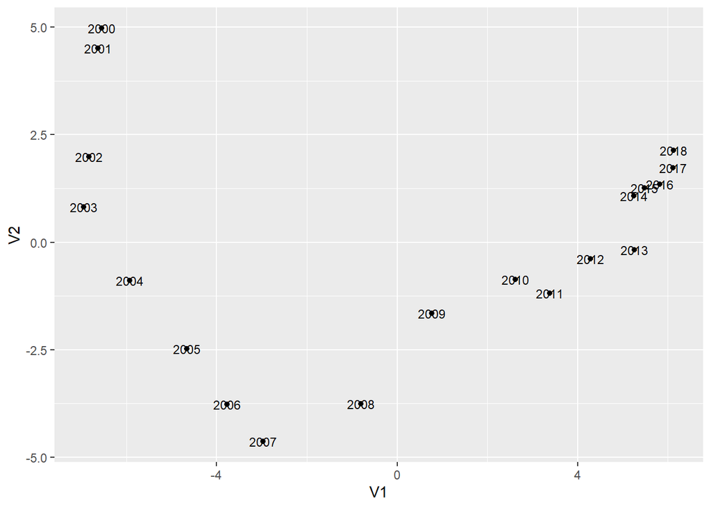

```r
dist.data2<-dist(data2.normal) # distance between units
autoplot(cmdscale(dist.data2, eig = TRUE), label = TRUE, label.size = 3)
```

As is visible is the picture below 4 dimensions are enough to get a very high value of R squared.

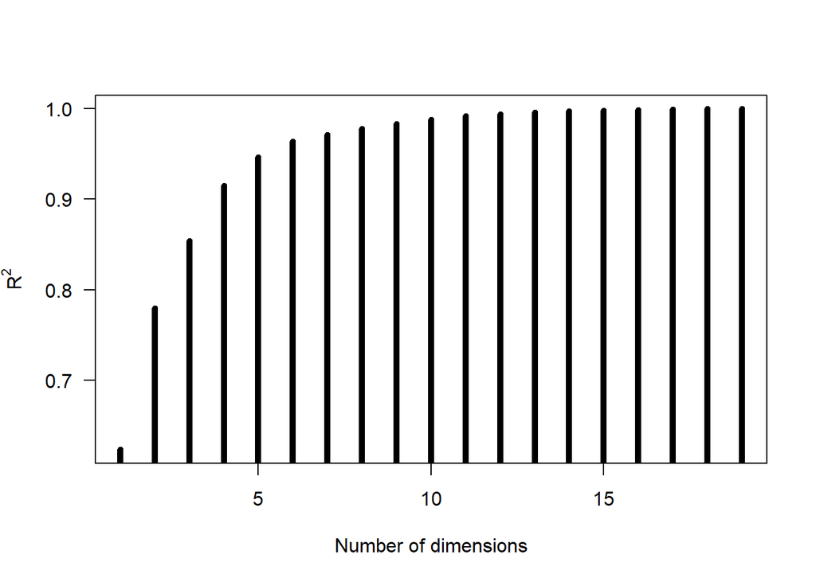

```r
r <- cmdscale(dist.data2, eig=TRUE)
plot(cumsum(r$eig) / sum(r$eig),
       type="h", lwd=5, las=1,
       xlab="Number of dimensions",
       ylab=expression(R^2))
```

#### Goodnes of fit

As we can see on the plot below we can see the correlation between the data is high for most of the observations. Thus I tried function `sim2diss()` for Stress Majorization of a Complicated Function to transform the data and the which impact of observation for stress function.

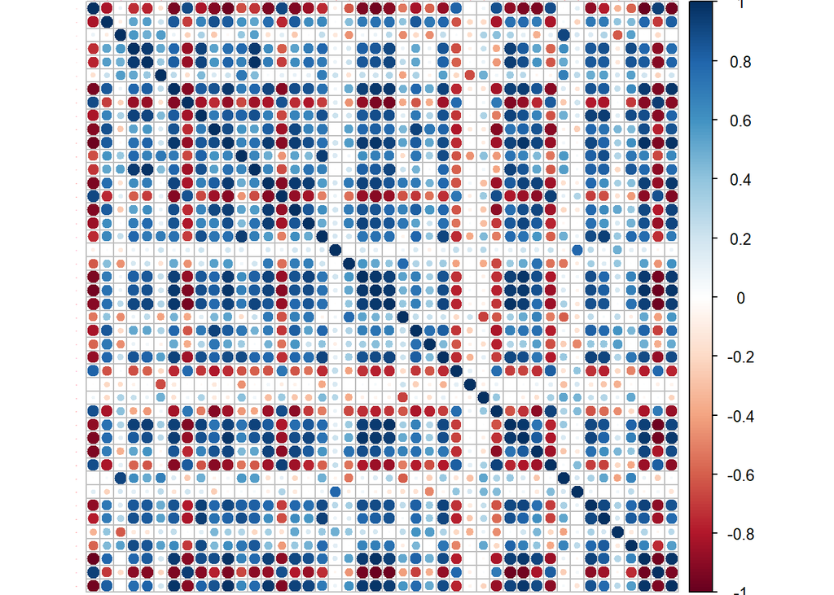

```r
sim<-cor(data2.normal)
corrplot(sim,tl.cex=0.01)
```

```r
dis2<-sim2diss(sim, method=1, to.dist=TRUE)
fit.data<-mds(dis2, ndim=4,  type="ratio")
fit.data
```

```
##
## Call:
## mds(delta = dis2, ndim = 4, type = "ratio")
##
## Model: Symmetric SMACOF
## Number of objects: 44
## Stress-1 value: 0.106
## Number of iterations: 36
```

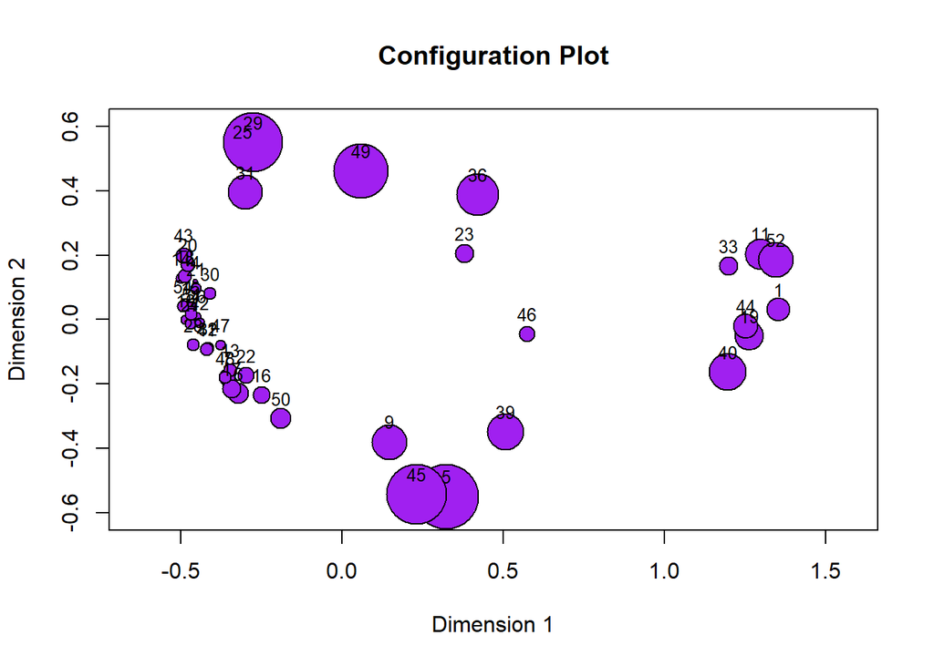

```r
# plot with impact of observation for stress function
plot(fit.data, pch=21, cex=as.numeric(fit.data$spp), bg="purple" )
```

##### Mantel test for similarity

Mantel test is a test for correlation between two matrices. It is used to check if transformed matrix did not lose the most important characteristics.

```r
mantel.test(as.matrix(sim), as.matrix(dis2))
```

```
## $z.stat
## [1] -204.6826
##
## $p
## [1] 0.001
##
## $alternative
## [1] "two.sided"
```

P - value of Mantel test is equal to 0.001, based on which we reject the null hypothesis H0 about significant difference between the simple correlation matrix and the one with stress function. Thus the matrices are similar.

##### Goodnes of fit of MDS

The next step is to check Goodnes of fit of MDS. To do this I used Kruskal’s stress (that was calculated above) and random stress function.

```r
# random stress function
stressvec<-randomstress(n=19, ndim=4, nrep=1)

(ratio <- fit.data$stress/ mean(stressvec))
```

```
## [1] 0.2672649
```

As we can see the value of ratio is close to 0.3. That is a quite poor result. Even adding more dimensions do not improve results. That gives an incentive to look for another method of which will give better explanation.

### PCA

#### Simple PCA

PCA is another method of dimension reduction. To perform a PCA first trying should be data normalization. After this I checked the distribution of the data. After normalization distribution is much closed to normal however the middle section is too low as for the normal distribution.

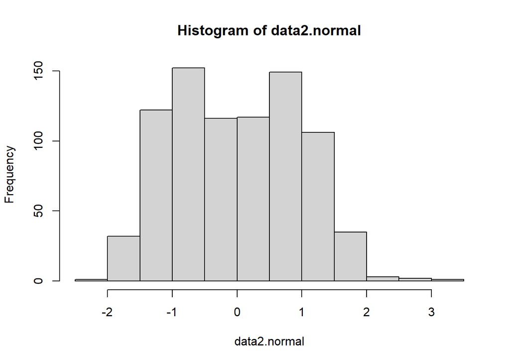

```r
data2.normal<-data.Normalization(data2, type="n1", normalization="column")
hist(data2.normal)
```

```r
# eigenvalues on the basis of covariance
data2.normal.cov<-cov(data2.normal)
data2_eigen<-eigen(data2.normal.cov)
data2_eigen$values
```

```
##  [1]  2.741835e+01  6.881931e+00  3.268746e+00  2.703366e+00  1.374928e+00
##  [6]  7.850960e-01  3.195903e-01  2.838350e-01  2.338666e-01  2.163559e-01
## [11]  1.579747e-01  1.008851e-01  8.527759e-02  5.308193e-02  4.931163e-02
## [16]  3.437694e-02  2.087622e-02  1.215315e-02  2.462649e-15  7.518609e-16
## [21]  6.960487e-16  6.902170e-16  5.821412e-16  4.052383e-16  4.024273e-16
## [26]  3.255022e-16  2.737605e-16  2.043718e-16  1.156369e-16  4.736956e-17
## [31]  3.670228e-17 -1.701902e-17 -3.830442e-17 -4.596487e-17 -1.212139e-16
## [36] -1.475909e-16 -2.883997e-16 -3.224953e-16 -3.531402e-16 -4.501408e-16
## [41] -4.993936e-16 -6.936689e-16 -1.090696e-15 -1.450302e-15
```

```r
X.pca1 <-prcomp(data2.normal)
head(X.pca1$rotation)
```

```
##          PC1         PC2          PC3         PC4          PC5         PC6
## 1  0.1858168  0.06164015  0.009588256  0.01927114 -0.069807342  0.07627423
## 4 -0.1575053 -0.07009244 -0.130893065  0.08225665 -0.028201449  0.33373103
## 5 -0.0148584  0.32974115  0.185013998  0.12682128 -0.168582074  0.13338525
## 6 -0.1591785  0.18925329  0.114789491  0.00531678 -0.007360071 -0.04809736
## 7 -0.1628077  0.13991765  0.180511736 -0.02168614 -0.013686649  0.03171059
## 9 -0.0573666  0.26677258 -0.232915083 -0.01989712 -0.352263724 -0.03158363
##             PC7         PC8          PC9        PC10         PC11        PC12
## 1 -2.886631e-03  0.10004047  0.030607735 -0.10627506 -0.089555296 -0.14108280
## 4 -4.694212e-01 -0.33043928 -0.016001138  0.15507357 -0.184277033 -0.23219753
## 5  1.421513e-01 -0.21886633  0.057809880  0.11282269  0.017136222  0.17516242
## 6  1.451299e-01 -0.07790963 -0.014780422  0.04814632 -0.125646353  0.07490721
## 7 -6.337159e-02  0.21470761 -0.007030197  0.07681036  0.009447281  0.27084930
## 9  4.352483e-05 -0.09086347 -0.461395726  0.02968717  0.240830985 -0.21046313
##          PC13        PC14       PC15         PC16        PC17        PC18
## 1  0.15819307 -0.05798646  0.1945320  0.022846100 -0.22621437  0.21010692
## 4  0.06135466  0.13768099  0.1939106  0.205035754  0.22255400 -0.04517358
## 5 -0.32398684 -0.13212791  0.0981490  0.064523397 -0.03565261 -0.03163851
## 6 -0.01013744 -0.02844483 -0.1798617  0.001488728  0.04042635 -0.01871835
## 7  0.13126417 -0.09550071  0.0825803  0.125035780  0.27779586 -0.42296734
## 9  0.09187819 -0.16893957 -0.1972283 -0.035704344 -0.04878283 -0.01703675
##          PC19
## 1 -0.32824341
## 4  0.15332055
## 5  0.19510138
## 6  0.03698989
## 7  0.14607865
## 9  0.11643907
```

### Rotated PCA

One of the types of PCA is rotated PCA. Using a specific algorithms which are looking for the simplest possible structure - for example varimax - we get results that are easier to interpret. However after using this we lose part of variance explanation. I used `principal()` function to do so.  
Table below presents loadings. We can see which countries have high value of loading in each column.

```r
X.pca2<-principal(data2.normal, nfactors=4, rotate="varimax")
print(loadings(X.pca2), digits=3, cutoff=0.4, sort=TRUE)
```

```
##
## Loadings:
##    RC1    RC2    RC3    RC4
## 1  -0.935
## 4   0.730         0.456
## 6   0.871  0.401
## 7   0.917
## 10  0.953
## 11 -0.942
## 13  0.878
## 14  0.783         0.531
## 15  0.955
## 17  0.889
## 18  0.911
## 19 -0.891
```

[output cut: 37 more lines]

```r
summary(X.pca2)
```

```
##
## Factor analysis with Call: principal(r = data2.normal, nfactors = 4, rotate = "varimax")
##
## Test of the hypothesis that 4 factors are sufficient.
## The degrees of freedom for the model is 776  and the objective function was  509.91
## The number of observations was  19  with Chi Square =  0  with prob <  1
##
## The root mean square of the residuals (RMSA) is  0.03
```

Cumulative Variance explanation is quite high for RC2 and RC3, for which it is equal to 0.849.

#### Quality of rotated PCA

For rotated PCA there a few measures based on which we can characterize the quality.

##### Complexity

Complexity tells us level of how much factors are hard to interpretation. The lower value the batter. Here we can see that 25 factor (Latvia) is the most complex. However there are some countries that are only a little less complicated.

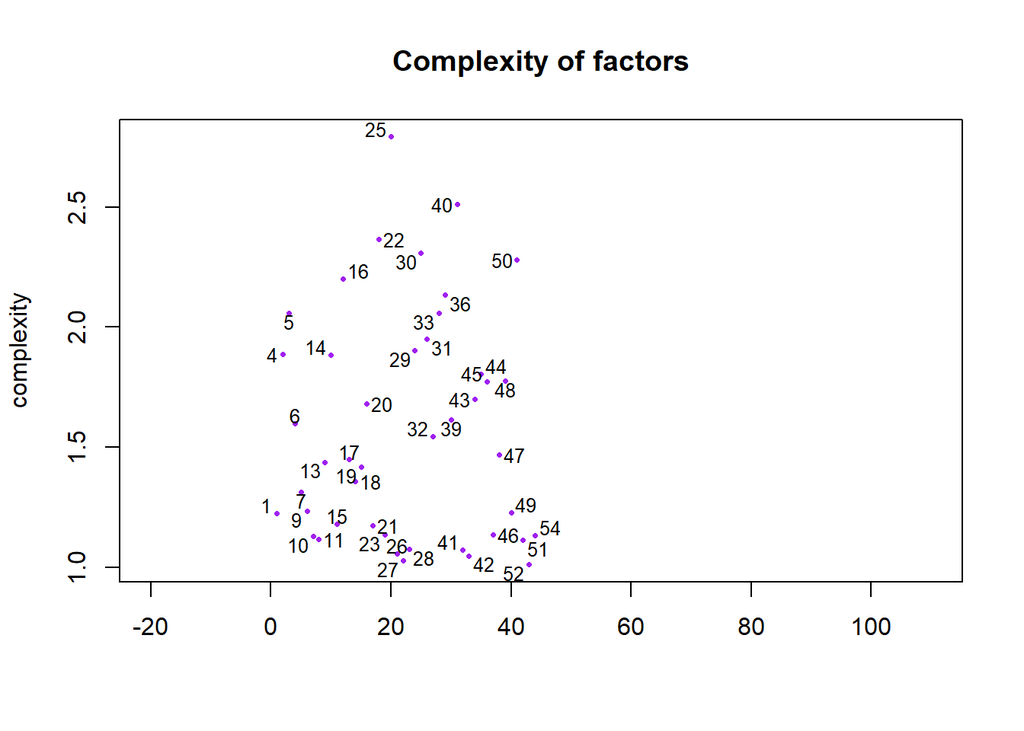

```r
plot(X.pca2$complexity, pch = 16, xlim=c(-20, 110), main="Complexity of factors", xlab=" ", ylab="complexity", col = "purple", cex =0.5)
pointLabel(X.pca2$complexity, labels=names(X.pca2$complexity), cex=0.8)
```

##### Uniquenesses

Another measure of quality is Uniquenesses, which points out the part of variance that is unique for a factor (best scenario is assigned only to one). The best value are low and close to zero. On ple plot below there are a lot of factors that seems to be quite unique which is a good information. The higher value is for factor number 36 (Moldova) which is close to 0.5. Nevertheless it is still quite a low value.

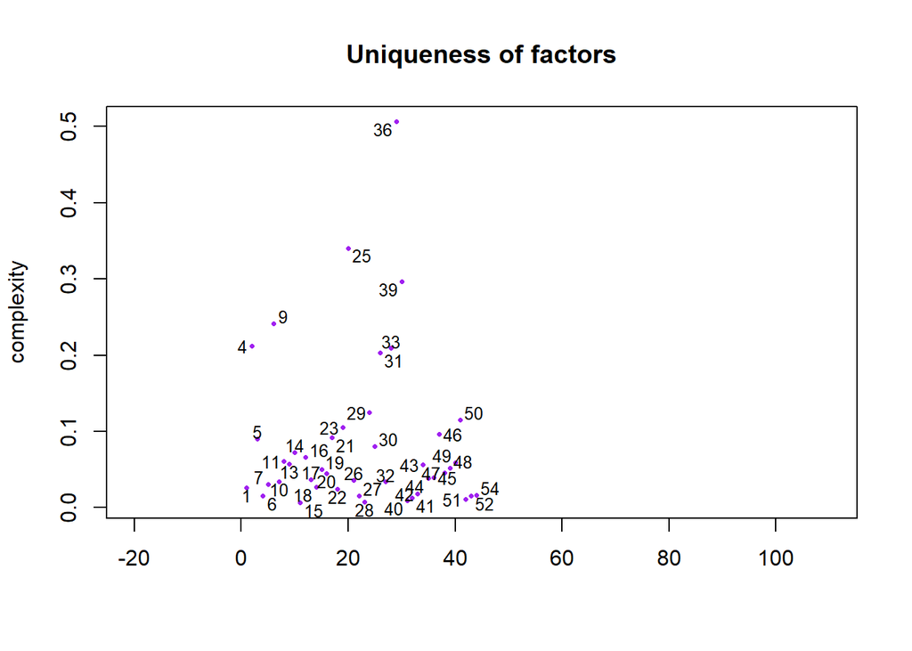

```r
plot(X.pca2$uniqueness, pch = 16, xlim=c(-20, 110), main="Uniqueness of factors", xlab=" ", ylab="complexity",col = "purple", cex =0.5)
pointLabel(X.pca2$uniqueness, labels=names(X.pca2$uniqueness), cex=0.8)
```

##### Removing one factor

As we can see above Uniqueness for each factor seems to be at an appropriate level. One factor is a candidate to be removed and see scenario without it.

```r
X.pca3<-principal(data3.normal, nfactors=4, rotate="varimax")
print(loadings(X.pca3), digits=3, cutoff=0.4, sort=TRUE)
```

```
##
## Loadings:
##    RC1    RC2    RC3    RC4
## 1  -0.919
## 4   0.710         0.494
## 6   0.855  0.472
## 7   0.911
## 10  0.944
## 11 -0.932
## 13  0.844  0.460
## 14  0.758         0.578
## 15  0.942
## 17  0.885
## 18  0.918
## 19 -0.890
```

[output cut: 36 more lines]

```r
summary(X.pca3)
```

```
##
## Factor analysis with Call: principal(r = data3.normal, nfactors = 4, rotate = "varimax")
##
## Test of the hypothesis that 4 factors are sufficient.
## The degrees of freedom for the model is 737  and the objective function was  488.56
## The number of observations was  19  with Chi Square =  81.43  with prob <  1
##
## The root mean square of the residuals (RMSA) is  0.03
```

##### Complexity

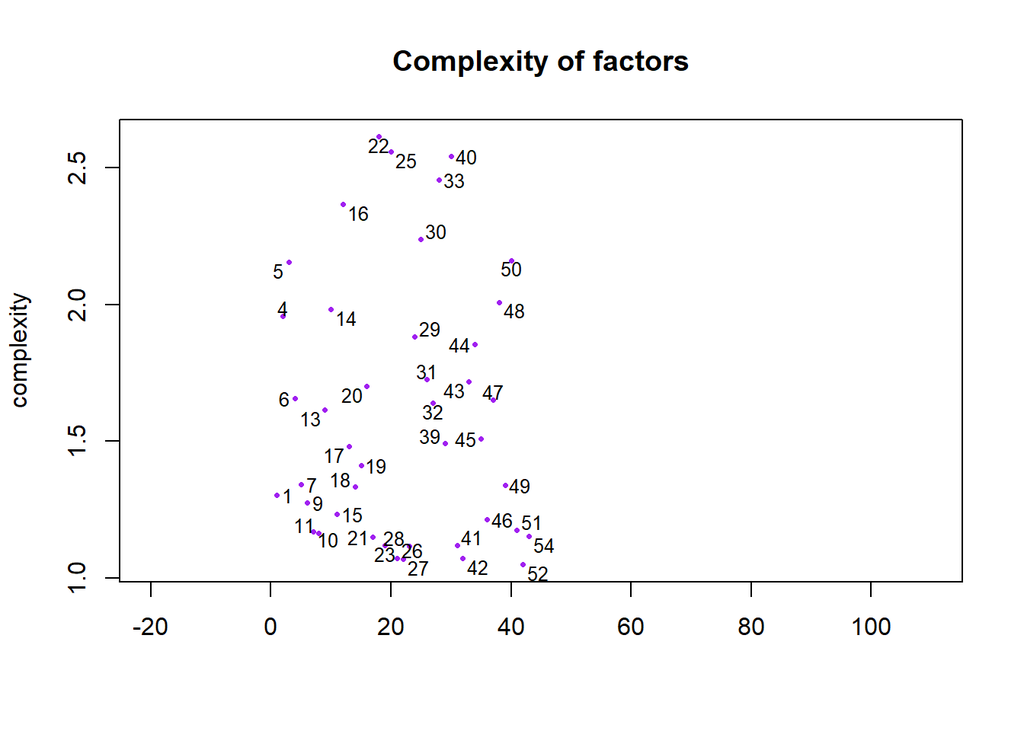

```r
plot(X.pca3$complexity, pch = 16, xlim=c(-20, 110), main="Complexity of factors", xlab=" ", ylab="complexity", col = "purple", cex =0.5)
pointLabel(X.pca3$complexity, labels=names(X.pca3$complexity), cex=0.8)
```

##### Uniqueness

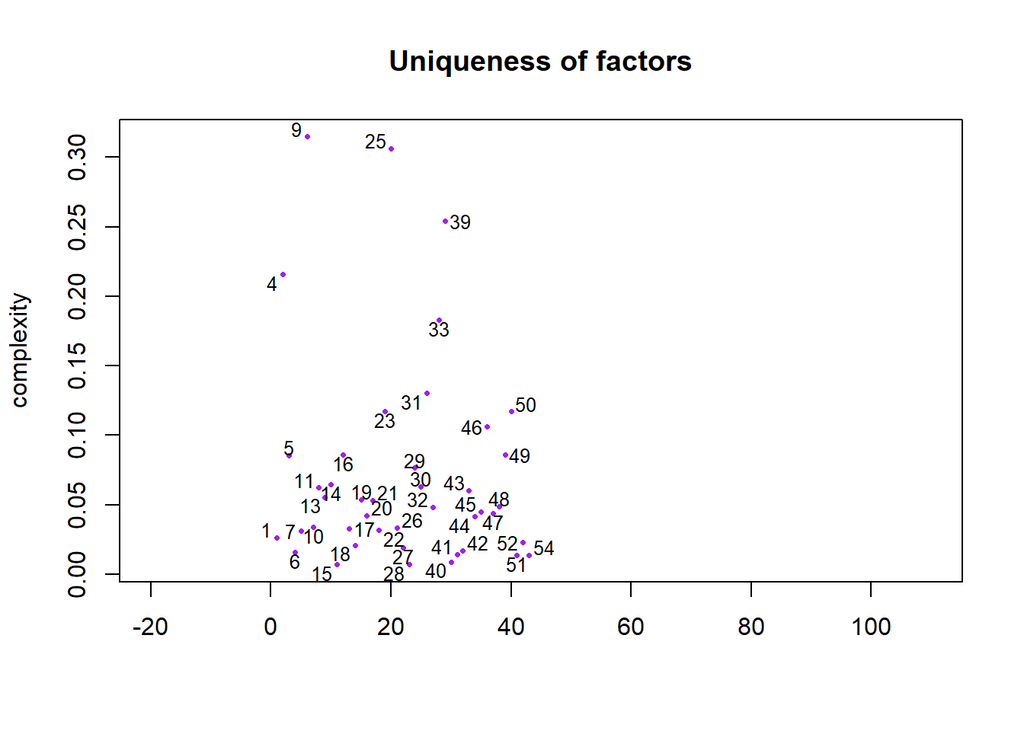

```r
plot(X.pca3$uniqueness, pch = 16, xlim=c(-20, 110), main="Uniqueness of factors", xlab=" ", ylab="complexity",col = "purple", cex =0.5)
pointLabel(X.pca3$uniqueness, labels=names(X.pca3$uniqueness), cex=0.8)
```

### Biblioghy

Allen M, (2017), *Factor Analysis: Varimax Rotation*, The SAGE Encyclopedia of Communication Research Methods